# Proyecto

**2. p-value = 5.39e-1:** Las semillas a las que se les aplico bioestimulante y germinaron a 20°C no presentaron diferencias significativas sobre aquellas semillas que se les aplico bioestimulante a 15°C. Esto indica que no hay diferencias en cuanto a la temperatura de germinación para un mismo tratamiento, ya que las plantas crecieron casi iguales en cuanto a la longitud de raiz.

**3. p-value = 1.02e-3:** Las semillas a las que se les aplico fertilizante y germinaron a 20°C presentaron diferencias significativas sobre aquellas semillas que se les aplico bioestimulante a 15°C. Esto nos indica que si hay diferencias en la longitud de raiz en cuanto al tratamiento utilizar.

**4. p-value = 2.54e-8:** Las semillas a las que se les aplico bioestimulante y germinaron a 20°C presentaron diferencias significativas sobre aquellas semillas que se les aplico fertilizante a 15°C. Esto nos indica que si hay diferencias en la longitud de raiz en cuanto al tratamiento utilizar.

**5. p-value = 5.27e-2:** Las semillas a las que se les aplico fertilizante y germinaron a 20°C no presentaron diferencias significativas sobre aquellas semillas que se les aplico fertilizante a 15°C. Esto nos indica que no hay diferencias en la longitud de raiz en cuanto a la temperatura de germinacion.

**6. p-value = 2.70e-5:** Las semillas a las que se les aplico fertilizante y germinaron a 20°C presentaron diferencias significativas sobre aquellas semillas que se les aplico bioestimulante a 20°C. Esto nos indica que si hay diferencias en la longitud de raiz en cuanto al tratamiento utilizar.

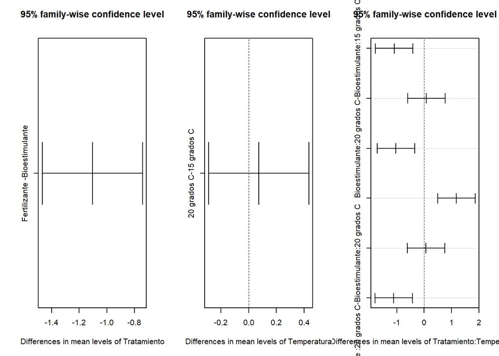

```r
# Variable Longitud de tallo
Est_Tukey2 <- TukeyHSD(Est_anova2)

par(mfrow=c(1,3))
plot(Est_Tukey2)
```

Se obtuvieron los siguientes resultados despues del analisis estadistico por Tukey:

**1. p-value = 0.0008:** Las semillas a las que se les aplico fertilizante y que crecieron a 15°C presentaron diferencias significativas sobre aquellas semillas que se les aplico bioestimulante a 15°C. Esto indica que si hay diferencias sobre el tratamiento que se utilizo en cuanto a la longitud de tallo de las plantas.

**2. p-value = 0.9878:** Las semillas a las que se les aplico bioestimulante y crecieron a 20°C no presentaron diferencias significativas sobre aquellas semillas que se les aplico bioestimulante a 15°C. Esto nos indica que no hay diferencias en el crecimiento del tallo de las plantas al variar la temperatura, en ambos casos las plantas crecieron bien al utilizar el tratamiento del bioestimulante.

**3. p-value = 0.0016:** Las plantas a las que se les aplico fertilizante a 20°C presentaron diferencias significativas sobre aquellas semillas que se les aplico bioestimulante a 15°C. Esto nos indica que si hay diferencias en el crecimiento del tallo de las plantas al variar la temperatura y el tratamiento.

**4. p-value = 0.0003:** Las plantas a las que se les aplico bioestimulante a 20°C presentaron diferencias significativas sobre aquellas semillas que se les aplico fertilizante a 15°C. Esto nos indica que si hay diferencias en el crecimiento del tallo de las plantas al variar la temperatura y el tratamiento.

**5. p-value = 0.9938:** Las semillas a las que se les aplico fertilizante a 20°C no presentaron diferencias significativas sobre aquellas semillas que se les aplico fertilizante a 15°C. Por lo que no hay diferencias en el crecimiento del tallo de las plantas al variar la temperatura.

**6. p-value = 0.0006:** Las semillas a las que se les aplico fertilizante a 20°C presentaron diferencias significativas sobre aquellas semillas que se les aplico bioestimulante a 20°C. Esto nos indica que si hay diferencias en el crecimiento del tallo de las plantas al variar el tratamiento.

## Ejercicio de correlación

Usando los datos “modernos” de la tabla Estanques_plantas, determinar si existe una correlación entre la biomasa de dos especies acuáticas de plantas en los estanques de Alaska: Carex y Arctophila.

**1.** Revisar si los datos cumplen todas las suposiciones de una correlación.

**2.** Reportar el coeficiente de correlación y su p-value

**3.** Explicar que significan estos valores y denle una interpretación a los resultados

```r
Estanque_filt <- Estanque_plantas[which(Estanque_plantas$Era == "Modern"),]
# Se filtraron los datos utilizando la funcion which para seleccionar solo los datos modernos de la columna "Era".

cor.test(Estanque_filt$Artophila,Estanque_filt$Carex,
         method = "pearson")
```

```
##
##  Pearson's product-moment correlation
##
## data:  Estanque_filt$Artophila and Estanque_filt$Carex
## t = 3.6467, df = 17, p-value = 0.001996
## alternative hypothesis: true correlation is not equal to 0
## 95 percent confidence interval:
##  0.2979541 0.8584059
## sample estimates:
##       cor
## 0.6625044
```

- **Coeficiente de correlación:** 0.6625
- **p-value:** 0.0019
- **Resultados:** El valor del coeficiente de correlación nos indica que los datos de la biomasa de las dos especies acuáticas de plantas *(Carex y Arctophilaque)* del estanque de Alaska, si estan relacionadas entre si. Asi mismo, al tener un p-value menor a 0.05 nos indica que esta relacion entre las especies si es significativa.